# Вариант 10. Акции Лукойла

# Загрузим данные из CSV-файла

```r
data <- read.table("D:\\МГУ\\Практикум\\Test3\\Stocs.csv",header=TRUE,sep=';')
head(data)
```

```
##     LcohDATE LcohCLOSE    SpxDATE SpxCLOSE   GoldDATE GoldCLOSE  BrentDATE
## 1 24.03.2022      5525 24.03.2022  4520.16 24.03.2022    1961.5 24.03.2022
## 2 25.03.2022      5206 25.03.2022  4543.06 25.03.2022    1957.6 25.03.2022
## 3 28.03.2022      5118 28.03.2022  4575.52 27.03.2022    1944.1 27.03.2022
## 4 29.03.2022      4922 29.03.2022  4631.60 28.03.2022    1924.9 28.03.2022
## 5 30.03.2022      5140 30.03.2022  4602.45 29.03.2022    1923.0 29.03.2022
## 6 31.03.2022      5680 31.03.2022  4530.41 30.03.2022    1929.4 30.03.2022
##   BrentCLOSE CopperDATE CopperCLOSE EurUsdDATE EurUsdCLOSE UsdRubDATE
## 1     118.20 24.03.2022    10415.77 24.03.2022     1.10083 24.03.2022
## 2     119.98 25.03.2022    10339.71 25.03.2022     1.09820 25.03.2022
## 3     114.12 27.03.2022    10318.77 27.03.2022     1.09811 27.03.2022
## 4     106.60 27.03.2022    10410.26 28.03.2022     1.09904 28.03.2022
## 5     108.56 29.03.2022    10491.83 29.03.2022     1.10910 29.03.2022
## 6     111.00 30.03.2022    10463.17 30.03.2022     1.11600 30.03.2022
##   UsdRubCLOSE    GasDATE GasCLOSE
## 1    102.2056 24.03.2022    5.449
## 2    101.2500 25.03.2022    5.543
## 3    100.9007 27.03.2022    5.652
## 4     95.7500 28.03.2022    5.491
## 5     85.0000 29.03.2022    5.333
## 6     83.4701 30.03.2022    5.577
```

# Удаляем повторяющиеся даты из каждого столбца

```r
df <- data[!duplicated(data$CopperDATE), ]
df <- df[!duplicated(df$LcohDATE), ]
df <- df[!duplicated(df$SpxDATE), ]
df <- df[!duplicated(df$GoldDATE), ]
df <- df[!duplicated(df$BrentDATE), ]
df <- df[!duplicated(df$EurUsdDATE), ]
df <- df[!duplicated(df$UsdRubDATE), ]
df <- df[!duplicated(df$GasDATE), ]
head(df)
```

```
##     LcohDATE LcohCLOSE    SpxDATE SpxCLOSE   GoldDATE GoldCLOSE  BrentDATE
## 1 24.03.2022      5525 24.03.2022  4520.16 24.03.2022    1961.5 24.03.2022
## 2 25.03.2022      5206 25.03.2022  4543.06 25.03.2022    1957.6 25.03.2022
## 3 28.03.2022      5118 28.03.2022  4575.52 27.03.2022    1944.1 27.03.2022
## 5 30.03.2022      5140 30.03.2022  4602.45 29.03.2022    1923.0 29.03.2022
## 6 31.03.2022      5680 31.03.2022  4530.41 30.03.2022    1929.4 30.03.2022
## 7 01.04.2022      5601 01.04.2022  4545.86 31.03.2022    1943.1 31.03.2022
##   BrentCLOSE CopperDATE CopperCLOSE EurUsdDATE EurUsdCLOSE UsdRubDATE
## 1     118.20 24.03.2022    10415.77 24.03.2022     1.10083 24.03.2022
## 2     119.98 25.03.2022    10339.71 25.03.2022     1.09820 25.03.2022
## 3     114.12 27.03.2022    10318.77 27.03.2022     1.09811 27.03.2022
## 5     108.56 29.03.2022    10491.83 29.03.2022     1.10910 29.03.2022
## 6     111.00 30.03.2022    10463.17 30.03.2022     1.11600 30.03.2022
## 7     105.65 31.03.2022    10442.23 31.03.2022     1.10725 31.03.2022
##   UsdRubCLOSE    GasDATE GasCLOSE
## 1    102.2056 24.03.2022    5.449
## 2    101.2500 25.03.2022    5.543
## 3    100.9007 27.03.2022    5.652
## 5     85.0000 29.03.2022    5.333
## 6     83.4701 30.03.2022    5.577
## 7     81.7081 31.03.2022    5.667
```

Записываем даты продажи акций Лукойла в массив дат

```r
dates <- c(data$LcohDATE)
dates <- dates[dates != ""] # Удаляем оттуда пустые строки
```

Далее реализуется следующий алгоритм: создаются массивы цен соотвествующих инструментов. Затем выясняем, продавались ли акции соотвествующих инструментов в даты из массива дат продаж акций Лукойла. Если в эту дату продавались все инструменты, то записываем стоимость продажи в соотвествующий массив

```r
Date <- numeric(0)
Lcoh <- numeric(0)
Spx <- numeric(0)
Gold <- numeric(0)
Brent <- numeric(0)
Copper <- numeric(0)
EurUsd <- numeric(0)
UsdRub <- numeric(0)
Gas <- numeric(0)

for (i in 1:length(dates)) {
  if (all(dates[i] %in% df$LcohDATE, dates[i] %in% df$SpxDATE,
          dates[i] %in% df$GoldDATE, dates[i] %in% df$BrentDATE,
          dates[i] %in% df$CopperDATE, dates[i] %in% df$EurUsdDATE,
          dates[i] %in% df$UsdRubDATE, dates[i] %in% df$GasDATE)) {
    Date <- append(Date, dates[i])
    Lcoh <- append(Lcoh, df[df$LcohDATE == dates[i], "LcohCLOSE"])
    Spx <- append(Spx, df[df$SpxDATE == dates[i], "SpxCLOSE"])
    Gold <- append(Gold, df[df$GoldDATE == dates[i], "GoldCLOSE"])
    Brent <- append(Brent, df[df$BrentDATE == dates[i], "BrentCLOSE"])
    Copper <- append(Copper, df[df$CopperDATE == dates[i], "CopperCLOSE"])
    EurUsd<- append(EurUsd, df[df$EurUsdDATE == dates[i], "EurUsdCLOSE"])
    UsdRub <- append(UsdRub, df[df$UsdRubDATE == dates[i], "UsdRubCLOSE"])
    Gas <- append(Gas, df[df$GasDATE == dates[i], "GasCLOSE"])
  }
}
```

# Объединяем результаты в датафрейм

```r
full_df <- data.frame(DATE=Date, Lcoh=Lcoh, SP500=Spx, Gold=Gold, Brent=Brent,
                      Copper=Copper, EurUsd=EurUsd, UsdRub=UsdRub, Gas=Gas)
```

Далее выяснилось, что в ценах продажи газа есть опечатки. Вместо чисел стоят различные строки, типа “06.сен”, “май.62” и т.д. Видимо, у меня криво скачался csv-файл с ценами газа. Ниже я преобразовываю этот столбец в numeric. Тогда на месте тех опечатков появляются NA. Затем я удаляю из датафрейма те строки, в которых в столбце цен газа стоят NA

```r
full_df$Gas <- as.numeric(full_df$Gas)
clean_df <- full_df[complete.cases(full_df$Gas), ]
head(clean_df)
```

```
##         DATE Lcoh   SP500   Gold  Brent   Copper  EurUsd   UsdRub   Gas
## 1 24.03.2022 5525 4520.16 1961.5 118.20 10415.77 1.10083 102.2056 5.449
## 2 25.03.2022 5206 4543.06 1957.6 119.98 10339.71 1.09820 101.2500 5.543
## 3 30.03.2022 5140 4602.45 1929.4 111.00 10463.17 1.11600  83.4701 5.577
## 4 31.03.2022 5680 4530.41 1943.1 105.65 10442.23 1.10725  81.7081 5.667
## 5 01.04.2022 5601 4545.86 1928.5 104.75 10373.89 1.10470  85.0000 5.722
## 6 04.04.2022 5557 4582.64 1932.0 107.98 10553.56 1.09749  82.2500 5.774
```

# Перейдем к логарифмическим доходностям

```r
r1 <- diff(log(clean_df$Lcoh))
r2 <- diff(log(clean_df$SP500))
r3 <- diff(log(clean_df$Gold))
r4 <- diff(log(clean_df$Brent))
r5 <- diff(log(clean_df$Copper))
r6 <- diff(log(clean_df$EurUsd))
r7 <- diff(log(clean_df$UsdRub))
r8 <- diff(log(clean_df$Gas))

rates <- cbind(r1,r2,r3,r4,r5,r6,r7,r8)
rownames(rates)<-as.character(as.Date(clean_df$DATE[2:length(clean_df$DATE)], "%d.%m.%Y"))
colnames(rates)<- colnames(clean_df)[2:length(clean_df)]
rates <- as.data.frame(rates)
head(rates)
```

```
##                    Lcoh        SP500         Gold        Brent       Copper
## 2022-03-25 -0.059471441  0.005053402 -0.001990254  0.014946957 -0.007329153
## 2022-03-30 -0.012758727  0.012987977 -0.014510159 -0.077794861  0.011869576
## 2022-03-31  0.099898153 -0.015776327  0.007075562 -0.049398457 -0.002003692
## 2022-04-01 -0.014006080  0.003404486 -0.007542137 -0.008555185 -0.006566429
## 2022-04-04 -0.007886759  0.008058323  0.001813237  0.030369466  0.017171873
## 2022-04-05 -0.044713547 -0.012631155 -0.002798944 -0.021530365 -0.005866348
##                  EurUsd       UsdRub         Gas
## 2022-03-25 -0.002391965 -0.009393765 0.017103765
## 2022-03-30  0.016078388 -0.193104222 0.006115127
## 2022-03-31 -0.007871400 -0.021335344 0.016008880
## 2022-04-01 -0.002305659  0.039498116 0.009658517
## 2022-04-04 -0.006548051 -0.032887867 0.009046687
## 2022-04-05 -0.006325259  0.020964119 0.050487636
```

# Построим регрессионную модель

```r
regrRates <- lm(Lcoh ~ SP500 + Gold + Brent + Copper + EurUsd + UsdRub + Gas, data=rates)
summary(regrRates)
```

```
##
## Call:
## lm(formula = Lcoh ~ SP500 + Gold + Brent + Copper + EurUsd +
##     UsdRub + Gas, data = rates)
##
## Residuals:
##       Min        1Q    Median        3Q       Max
## -0.135152 -0.009715 -0.001346  0.010375  0.148629
##
## Coefficients:
##              Estimate Std. Error t value Pr(>|t|)
## (Intercept)  0.001087   0.001458   0.746   0.4565
## SP500       -0.046601   0.119762  -0.389   0.6975
## Gold         0.274687   0.180661   1.520   0.1294
## Brent       -0.021718   0.064975  -0.334   0.7384
## Copper       0.043274   0.110170   0.393   0.6947
## EurUsd       0.104597   0.293081   0.357   0.7214
## UsdRub       0.150343   0.058191   2.584   0.0102 *
## Gas          0.052742   0.028873   1.827   0.0687 .
## ---
## Signif. codes:  0 '***' 0.001 '**' 0.01 '*' 0.05 '.' 0.1 ' ' 1
##
## Residual standard error: 0.02614 on 315 degrees of freedom
## Multiple R-squared:  0.03755,    Adjusted R-squared:  0.01617
## F-statistic: 1.756 on 7 and 315 DF,  p-value: 0.09566
```

Выяснилось, что только предиктор UsdRub оказался статистически значимым, так как соответствующее p-value = 0.0102 < 0.05. Остальные p-value превышают уровень значимости. Кроме того, видим что модель является вырожденной, так как p-value = 0.09566 > 0.05. Коэффициент детерминации крайне низок, ей объясняется всего 3,7 процента доходностей акций Лукойла.

Переоценим модель только для значимых переменных и без константы

```r
regrRates1 <- lm(Lcoh ~ UsdRub - 1, data=rates)
summary(regrRates1)
```

```
##
## Call:
## lm(formula = Lcoh ~ UsdRub - 1, data = rates)
##
## Residuals:
##       Min        1Q    Median        3Q       Max
## -0.132351 -0.008791  0.000014  0.011304  0.148148
##
## Coefficients:
##        Estimate Std. Error t value Pr(>|t|)
## UsdRub  0.12463    0.05639    2.21   0.0278 *
## ---
## Signif. codes:  0 '***' 0.001 '**' 0.01 '*' 0.05 '.' 0.1 ' ' 1
##
## Residual standard error: 0.02617 on 322 degrees of freedom
## Multiple R-squared:  0.01494,    Adjusted R-squared:  0.01188
## F-statistic: 4.884 on 1 and 322 DF,  p-value: 0.0278
```

Переоцененная модель уже не является вырожденной, так как p-value = 0.0278 < 0.05. Однако коэффициент детерминации меньше предыдущей модели.

# Исследуем остатки

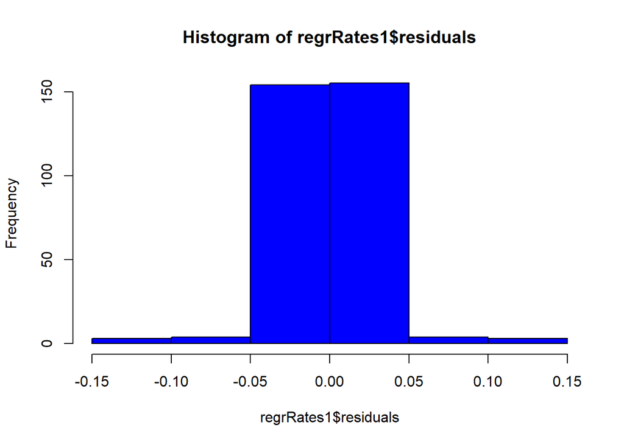

```r
hist(regrRates1$residuals, col='blue') # Гистограмма остатков
```

По гистограмме видно, что остатки не имеют нормальное распределение

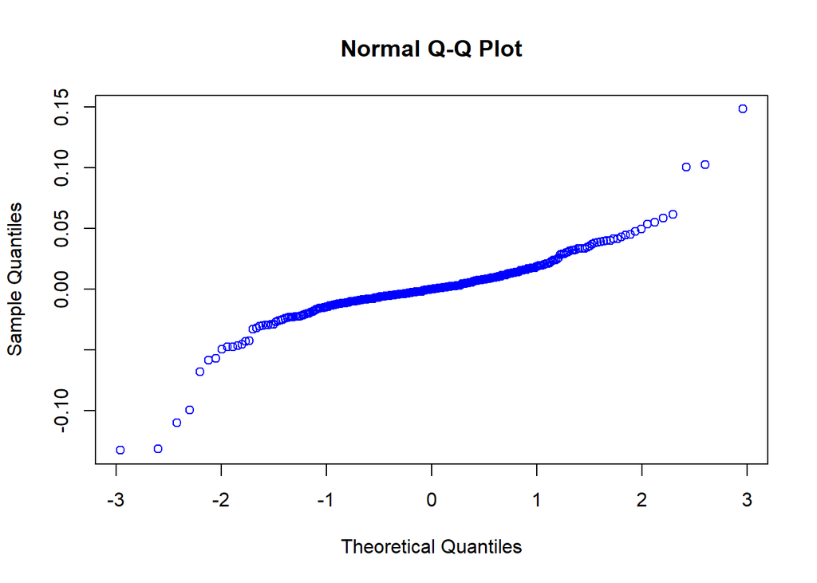

```r
qqnorm(regrRates1$residuals,col = "blue") #QQ-plot
```

Проведем тест Шапиро-Уилка

```r
shapiro.test(regrRates1$residuals)
```

```
##
##  Shapiro-Wilk normality test
##
## data:  regrRates1$residuals
## W = 0.86387, p-value = 3.06e-16
```

По результатам теста отвергаем гипотезу о нормальном распределении остатков

Исследуем автокорреляции остатков

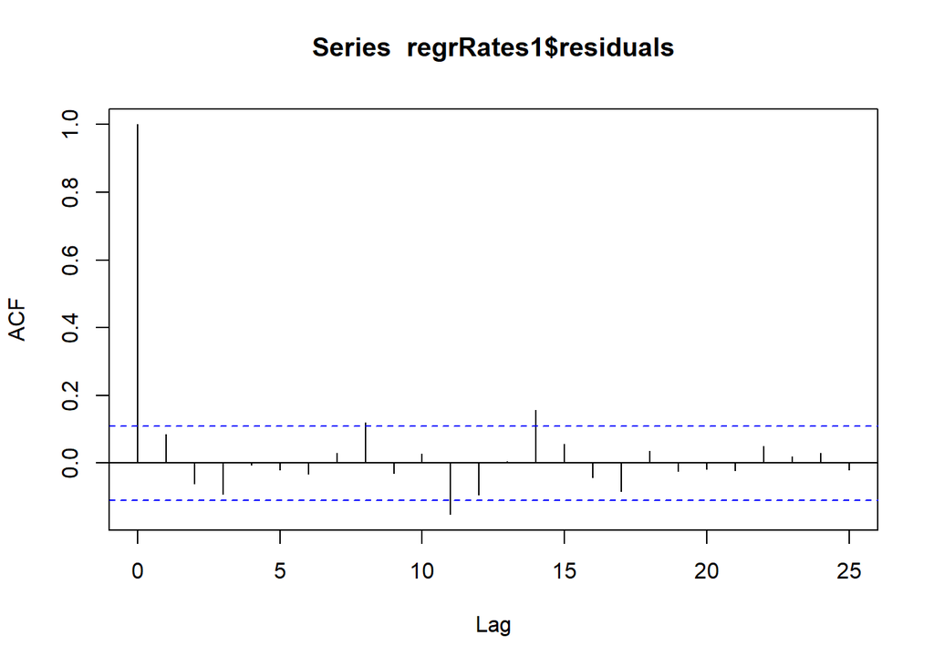

```r
acf(regrRates1$residuals)
```

Видим, что ACF остатков выходит за полосу ±2/sqrt(n), таким образом не является белым шумом